# Prabal Ghosh Workshop-3_R Notebook

# #Workshop 3 : dplyr & ggplot

##Exercise 1: Filtering and selecting with dplyr

Read in the genomes.csv file into a variable called genomes. Perform the following operations: Make a list of the 5 organisms with the largest genomes Of the organisms which have more than 40 chromosomes which one comes first, alphabetically? Do any organisms containing a plasmid, also have more than one chromosome? Make a version of the data containing only the columns from Chromosomes onwards. Move the Size column to the front of the tibble. Select just the columns which start with “O”. How many different groups are there? ===

```r
library(dplyr)
library(datasets)
```

```r
library(ggplot2)
genom_data<- read.csv("C:\\Users\\praba\\Desktop\\uca1\\M1\\R programming\\class-6 workshop-3\\genomes.csv")
head(genom_data,10)
```

|  | Organism | Groups | Size | Chromosomes | Organelles | Plasmids | Assemblies |
| --- | --- | --- | --- | --- | --- | --- | --- |
| 1 | 'Brassica napus' phytoplasma | Bacteria;Terrabacteria group;Tenericutes | 0.743598 | 0 | 0 | 0 | 1 |
| 2 | 'Candidatus Kapabacteria' thiocyanatum | Bacteria;FCB group;Bacteroidetes/Chlorobi group | 3.272990 | 0 | 0 | 0 | 1 |
| 3 | 'Catharanthus roseus' aster yellows phytoplasma | Bacteria;Terrabacteria group;Tenericutes | 0.603949 | 1 | 0 | 1 | 1 |
| 4 | 'Chrysanthemum coronarium' phytoplasma | Bacteria;Terrabacteria group;Tenericutes | 0.739592 | 0 | 0 | 0 | 1 |
| 5 | 'Echinacea purpurea' witches'-broom phytoplasma | Bacteria;Terrabacteria group;Tenericutes | 0.545427 | 0 | 0 | 0 | 1 |
| 6 | 'Osedax' symbiont bacterium Rs2_46_30_T18 | Bacteria;unclassified Bacteria;unclassified Bacteria (miscellaneous) | 4.021830 | 0 | 0 | 0 | 1 |
| 7 | 'Sphingomonas ginsengisoli' Hoang et al. 2012 | Bacteria;Proteobacteria;Alphaproteobacteria | 3.036390 | 0 | 0 | 0 | 1 |
| 8 | Abaca bunchy top virus | Viruses;Other;Nanoviridae | 0.006422 | 6 | 0 | 0 | 2 |
| 9 | Abalone herpesvirus Victoria/AUS/2009 | Viruses;Other;Malacoherpesviridae | 0.211518 | 1 | 0 | 0 | 1 |
| 10 | Abalone shriveling syndrome-associated virus | Viruses;Other;Other | 0.034952 | 1 | 0 | 0 | 1 |

1.Make a list of the 5 organisms with the largest genomes

```r
genom_data_1<- arrange(genom_data,desc(Size))
head(genom_data_1,5)
```

|  | Organism | Groups | Size | Chromosomes | Organelles | Plasmids | Assemblies |
| --- | --- | --- | --- | --- | --- | --- | --- |
| 1 | Ambystoma mexicanum | Eukaryota;Animals;Amphibians | 32396.4 | 20 | 0 | 0 | 2 |
| 2 | Pinus lambertiana | Eukaryota;Plants;Land Plants | 27602.7 | 0 | 0 | 0 | 1 |
| 3 | Sequoia sempervirens | Eukaryota;Plants;Land Plants | 26537.2 | 0 | 1 | 0 | 1 |
| 4 | Picea glauca | Eukaryota;Plants;Land Plants | 24633.1 | 0 | 1 | 0 | 3 |
| 5 | Pinus taeda | Eukaryota;Plants;Land Plants | 22103.6 | 0 | 0 | 0 | 1 |

2.Of the organisms which have more than 40 chromosomes which one comes first, alphabetically?

```r
data_1<-filter(genom_data, Chromosomes >= 40)
head(arrange(data_1,Organism),1)
```

|  | Organism | Groups | Size | Chromosomes | Organelles | Plasmids | Assemblies |
| --- | --- | --- | --- | --- | --- | --- | --- |
| 1 | Carassius auratus | Eukaryota;Animals;Fishes | 1820.64 | 59 | 1 | 0 | 1 |

3.Do any organisms containing a plasmid, also have more than one chromosome?

```r
genom_data%>% filter(Plasmids != 0 & Chromosomes>1)
```

| Organism | Groups | Size | Chromosomes | Organelles | Plasmids | Assemblies |
| --- | --- | --- | --- | --- | --- | --- |
| Agrobacterium fabrum | Bacteria;Proteobacteria;Alphaproteobacteria | 5.67426 | 2 | 0 | 2 | 9 |
| Agrobacterium tumefaciens | Bacteria;Proteobacteria;Alphaproteobacteria | 7.27330 | 2 | 0 | 3 | 66 |
| Agrobacterium vitis | Bacteria;Proteobacteria;Alphaproteobacteria | 6.32095 | 2 | 0 | 5 | 13 |
| Aliivibrio fischeri | Bacteria;Proteobacteria;Gammaproteobacteria | 4.27372 | 2 | 0 | 1 | 37 |
| Aliivibrio salmonicida | Bacteria;Proteobacteria;Gammaproteobacteria | 4.65566 | 2 | 0 | 4 | 2 |
| Aliivibrio wodanis | Bacteria;Proteobacteria;Gammaproteobacteria | 4.63513 | 2 | 0 | 4 | 7 |
| Asticcacaulis excentricus | Bacteria;Proteobacteria;Alphaproteobacteria | 4.30878 | 2 | 0 | 2 | 2 |
| Brassica napus | Eukaryota;Plants;Land Plants | 976.19100 | 19 | 2 | 1 | 2 |
| Burkholderia ambifaria | Bacteria;Proteobacteria;Betaproteobacteria | 8.09590 | 3 | 0 | 1 | 10 |
| Burkholderia cepacia | Bacteria;Proteobacteria;Betaproteobacteria | 8.60595 | 3 | 0 | 1 | 136 |

[output cut: 86 more lines]

4.Make a version of the data containing only the columns from Chromosomes onwards.

```r
# names(genom_data)
genom_data %>% select(Chromosomes:Assemblies)
```

| Chromosomes | Organelles | Plasmids | Assemblies |
| --- | --- | --- | --- |
| 0 | 0 | 0 | 1 |
| 0 | 0 | 0 | 1 |
| 1 | 0 | 1 | 1 |
| 0 | 0 | 0 | 1 |
| 0 | 0 | 0 | 1 |
| 0 | 0 | 0 | 1 |
| 0 | 0 | 0 | 1 |
| 6 | 0 | 0 | 2 |
| 1 | 0 | 0 | 1 |
| 1 | 0 | 0 | 1 |

[output cut: 9990 more lines]

```r
genom_data %>% select(4:7)
```

| Chromosomes | Organelles | Plasmids | Assemblies |
| --- | --- | --- | --- |
| 0 | 0 | 0 | 1 |
| 0 | 0 | 0 | 1 |
| 1 | 0 | 1 | 1 |
| 0 | 0 | 0 | 1 |
| 0 | 0 | 0 | 1 |
| 0 | 0 | 0 | 1 |
| 0 | 0 | 0 | 1 |
| 6 | 0 | 0 | 2 |
| 1 | 0 | 0 | 1 |
| 1 | 0 | 0 | 1 |

[output cut: 9990 more lines]

5.Move the Size column to the front of the tibble.

```r
genom_data_Sorted = genom_data %>% select("Size", everything())
genom_data_Sorted
```

| Size | Organism | Groups | Chromosomes | Organelles | Plasmids | Assemblies |
| --- | --- | --- | --- | --- | --- | --- |
| 7.43598e-01 | 'Brassica napus' phytoplasma | Bacteria;Terrabacteria group;Tenericutes | 0 | 0 | 0 | 1 |
| 3.27299e+00 | 'Candidatus Kapabacteria' thiocyanatum | Bacteria;FCB group;Bacteroidetes/Chlorobi group | 0 | 0 | 0 | 1 |
| 6.03949e-01 | 'Catharanthus roseus' aster yellows phytoplasma | Bacteria;Terrabacteria group;Tenericutes | 1 | 0 | 1 | 1 |
| 7.39592e-01 | 'Chrysanthemum coronarium' phytoplasma | Bacteria;Terrabacteria group;Tenericutes | 0 | 0 | 0 | 1 |
| 5.45427e-01 | 'Echinacea purpurea' witches'-broom phytoplasma | Bacteria;Terrabacteria group;Tenericutes | 0 | 0 | 0 | 1 |
| 4.02183e+00 | 'Osedax' symbiont bacterium Rs2_46_30_T18 | Bacteria;unclassified Bacteria;unclassified Bacteria (miscellaneous) | 0 | 0 | 0 | 1 |
| 3.03639e+00 | 'Sphingomonas ginsengisoli' Hoang et al. 2012 | Bacteria;Proteobacteria;Alphaproteobacteria | 0 | 0 | 0 | 1 |
| 6.42200e-03 | Abaca bunchy top virus | Viruses;Other;Nanoviridae | 6 | 0 | 0 | 2 |
| 2.11518e-01 | Abalone herpesvirus Victoria/AUS/2009 | Viruses;Other;Malacoherpesviridae | 1 | 0 | 0 | 1 |
| 3.49520e-02 | Abalone shriveling syndrome-associated virus | Viruses;Other;Other | 1 | 0 | 0 | 1 |

[output cut: 9990 more lines]

6.Select just the columns which start with “O”.

```r
genom_data %>% select(starts_with('O'))
```

| Organism | Organelles |
| --- | --- |
| 'Brassica napus' phytoplasma | 0 |
| 'Candidatus Kapabacteria' thiocyanatum | 0 |
| 'Catharanthus roseus' aster yellows phytoplasma | 0 |
| 'Chrysanthemum coronarium' phytoplasma | 0 |
| 'Echinacea purpurea' witches'-broom phytoplasma | 0 |
| 'Osedax' symbiont bacterium Rs2_46_30_T18 | 0 |
| 'Sphingomonas ginsengisoli' Hoang et al. 2012 | 0 |
| Abaca bunchy top virus | 0 |
| Abalone herpesvirus Victoria/AUS/2009 | 0 |
| Abalone shriveling syndrome-associated virus | 0 |

[output cut: 9990 more lines]

7.How many different groups are there?

```r
genom_data %>% distinct(Groups) %>% nrow()
```

```
## [1] 310
```

#Exercise 2: More clever filtering

Read in the “cancer_stats.csv” file into a variable called cancer then answer the following questions. For which Digestive System cancer types are there more female cases than male cases? Which cancer types (Class and Site) have no data (NA) for males? Which cancer types (Class and Site) have no data (NA) for females? Which cancer type has the best survival rate for males? Which cancer Sites have “acute” in their names? Out of tongue, kidney, breast and pancreas, which is classed as a soft tissue cancer? === Read in the “cancer_stats.csv” file into a variable called cancer then answer the following questions.

```r
cancer_data_1<- read.csv("C:\\Users\\praba\\Desktop\\uca1\\M1\\R programming\\class-6 workshop-3\\cancer_stats.csv")
head(cancer_data_1,15)
```

|  | Class | Site | Male.Cases | Female.Cases | Male.Deaths | Female.Deaths |
| --- | --- | --- | --- | --- | --- | --- |
| 1 | Oral | Tongue | 12550 | 4510 | 2220 | 800 |
| 2 | Oral | Mouth | 8430 | 5880 | 1800 | 940 |
| 3 | Oral | Pharynx | 14450 | 3420 | 2660 | 790 |
| 4 | Digestive System | Eosophagus | 13750 | 3900 | 13020 | 3060 |
| 5 | Digestive System | Stomach | 17230 | 10280 | 6800 | 4340 |
| 6 | Digestive System | Small intestine | 5610 | 1980 | 890 | 700 |
| 7 | Digestive System | Colon | 51690 | 49730 | 27640 | 23380 |
| 8 | Digestive System | liver | 29480 | 12550 | 21600 | 10180 |
| 9 | Digestive System | gall | 5810 | 6550 | 1610 | 2350 |
| 10 | Digestive System | pancreas | 29940 | 26830 | 23800 | 21950 |

[output cut: 5 more lines]

2.For which Digestive System cancer types are there more female cases than male cases?

```r
cancer_data_1 %>% filter(Class=="Digestive System") %>% filter(Female.Cases>Male.Cases) %>% select(Class, Site,Male.Cases,Female.Cases)
```

| Class | Site | Male.Cases | Female.Cases |
| --- | --- | --- | --- |
| Digestive System | gall | 5810 | 6550 |

3.Which cancer types (Class and Site) have no data (NA) for males?

```r
# cancer_data_1 %>% filter(Male.Cases == NA) %>% select(Class, Site)
cancer_data_1 %>% filter(is.na(Male.Cases))
```

| Class | Site | Male.Cases | Female.Cases | Male.Deaths | Female.Deaths |
| --- | --- | --- | --- | --- | --- |
| genital | cervix | NA | 13170 | NA | 4250 |
| genital | uterine corpus | NA | 61880 | NA | 12160 |
| genital | Ovary | NA | 22530 | NA | 13980 |
| genital | Vulva | NA | 6070 | NA | 1280 |
| genital | female genital | NA | 5350 | NA | 1430 |

4.Which cancer types (Class and Site) have no data (NA) for females?

```r
# cancer_data_1 %>% filter(Female.Cases == NA) %>% select(Class, Site)
cancer_data_1 %>% filter(is.na(Female.Cases))
```

| Class | Site | Male.Cases | Female.Cases | Male.Deaths | Female.Deaths |
| --- | --- | --- | --- | --- | --- |
| genital | Prostate | 174650 | NA | 31620 | NA |
| genital | Testis | 9560 | NA | 410 | NA |
| genital | male genital | 2080 | NA | 410 | NA |

5.Which cancer type has the best survival rate for males?

```r
library(tidyr)

cancer_data_1 %>% drop_na(Male.Cases) %>% mutate(male_raio=Male.Deaths/Male.Cases) %>% arrange(male_raio)%>% slice(1)
```

| Class | Site | Male.Cases | Female.Cases | Male.Deaths | Female.Deaths | male_raio |
| --- | --- | --- | --- | --- | --- | --- |
| genital | Testis | 9560 | NA | 410 | NA | 0.04288703 |

6.Which cancer Sites have “acute” in their names?

```r
cancer_data_1 %>% filter(grepl('acute', Site))
```

| Class | Site | Male.Cases | Female.Cases | Male.Deaths | Female.Deaths |
| --- | --- | --- | --- | --- | --- |
| leukemia | acute lymphocytic | 3280 | 2650 | 850 | 650 |
| leukemia | acute myeloid | 11650 | 9800 | 6290 | 4630 |

```r
library(stringr)
cancer_data_1 %>% filter(str_detect(Site,"acute"))
```

| Class | Site | Male.Cases | Female.Cases | Male.Deaths | Female.Deaths |
| --- | --- | --- | --- | --- | --- |
| leukemia | acute lymphocytic | 3280 | 2650 | 850 | 650 |
| leukemia | acute myeloid | 11650 | 9800 | 6290 | 4630 |

7.Out of tongue, kidney, breast and pancreas, which is classed as a soft tissue cancer?

```r
# vec1=c('tongue', 'kidney', 'breast','pancreas')
cancer_data_1 %>% filter(Class=='soft tissue') %>% filter(Site== 'tongue'| Site== 'kidney'| Site=='breast'|Site== 'pancreas' )
```

| Class | Site | Male.Cases | Female.Cases | Male.Deaths | Female.Deaths |
| --- | --- | --- | --- | --- | --- |
| soft tissue | breast | 2670 | 268600 | 500 | 41760 |

```r
vec1=c('tongue', 'kidney', 'breast','pancreas')
cancer_data_1 %>% filter(Class=='soft tissue') %>% filter(tolower(Site) %in% vec1 )
```

| Class | Site | Male.Cases | Female.Cases | Male.Deaths | Female.Deaths |
| --- | --- | --- | --- | --- | --- |
| soft tissue | breast | 2670 | 268600 | 500 | 41760 |

#Exercise 3: dplyr and ggplot

Load the starwars dataset.

Which variable (column) has the highest number of missing values?

How many humans contains the starwars dataset? show them by gender.

From which homeworld do the most individuals (rows) come from?

Create a barplot of the gender distribution of the starwars Universe, set the title : “Gender distribution of the sw Universe”. Make the colors of the columns depend on the gender, modify the colour using the command : scale_fill_manual.

Draw the densities for the height variable of feminines and masculines only.

# Draw a segmented barplot for the variable ‘sex’. The colors depend on the hair colours. Show the proportions [0,1] on the y-axis.

```r
data(starwars)
starwars
```

| name | height | mass | hair_color | skin_color | eye_color | birth_year | sex | gender | homeworld | species | films | vehicles | starships |
| --- | --- | --- | --- | --- | --- | --- | --- | --- | --- | --- | --- | --- | --- |
| Luke Skywalker | 172 | 77.0 | blond | fair | blue | 19.0 | male | masculine | Tatooine | Human |  |  |  |
| C-3PO | 167 | 75.0 | NA | gold | yellow | 112.0 | none | masculine | Tatooine | Droid |  |  |  |
| R2-D2 | 96 | 32.0 | NA | white, blue | red | 33.0 | none | masculine | Naboo | Droid |  |  |  |
| Darth Vader | 202 | 136.0 | none | white | yellow | 41.9 | male | masculine | Tatooine | Human |  |  |  |
| Leia Organa | 150 | 49.0 | brown | light | brown | 19.0 | female | feminine | Alderaan | Human |  |  |  |
| Owen Lars | 178 | 120.0 | brown, grey | light | blue | 52.0 | male | masculine | Tatooine | Human |  |  |  |
| Beru Whitesun lars | 165 | 75.0 | brown | light | blue | 47.0 | female | feminine | Tatooine | Human |  |  |  |
| R5-D4 | 97 | 32.0 | NA | white, red | red | NA | none | masculine | Tatooine | Droid |  |  |  |
| Biggs Darklighter | 183 | 84.0 | black | light | brown | 24.0 | male | masculine | Tatooine | Human |  |  |  |
| Obi-Wan Kenobi | 182 | 77.0 | auburn, white | fair | blue-gray | 57.0 | male | masculine | Stewjon | Human |  |  |  |

[output cut: 77 more lines]

2.Which variable (column) has the highest number of missing values?

```r
a<-sort( colSums( sapply(starwars, is.na) ) )
a
```

```
##       name skin_color  eye_color      films   vehicles  starships        sex
##          0          0          0          0          0          0          4
##     gender    species hair_color     height  homeworld       mass birth_year
##          4          4          5          6         10         28         44
```

2.How many humans contains the starwars dataset? show them by gender.

```r
# starwars %>% drop_na(gender,species) %>%filter(species == 'Human' & gender=='feminine')%>%summarize(n=n())
starwars%>%drop_na(gender,species) %>% count( (species == 'Human' & gender=='masculine'))
```

| (species == "Human" & gender == "masculine") | n |
| --- | --- |
| FALSE | 57 |
| TRUE | 26 |

```r
starwars %>% drop_na(gender,species)%>% group_by(gender)  %>% count((species == 'Human' & gender=='masculine'))
```

| gender | (species == "Human" & gender == "masculine") | n |
| --- | --- | --- |
| feminine | FALSE | 17 |
| masculine | FALSE | 40 |
| masculine | TRUE | 26 |

```r
starwars %>% filter( species == 'Human' ) %>% group_by(gender) %>% summarise(count_m_f=(n=n()))
```

| gender | count_m_f |
| --- | --- |
| feminine | 9 |
| masculine | 26 |

3.From which homeworld do the most individuals (rows) come from?

```r
# starwars
starwars %>% group_by(homeworld) %>% summarise(count_homeworld=(n=n())) %>% arrange(desc(count_homeworld))
```

| homeworld | count_homeworld |
| --- | --- |
| Naboo | 11 |
| Tatooine | 10 |
| NA | 10 |
| Alderaan | 3 |
| Coruscant | 3 |
| Kamino | 3 |
| Corellia | 2 |
| Kashyyyk | 2 |
| Mirial | 2 |
| Ryloth | 2 |

[output cut: 39 more lines]

4.Create a barplot of the gender distribution of the starwars Universe, set the title : “Gender distribution of the sw Universe”. Make the colors of the columns depend on the gender, modify the colour using the command : scale_fill_manual.

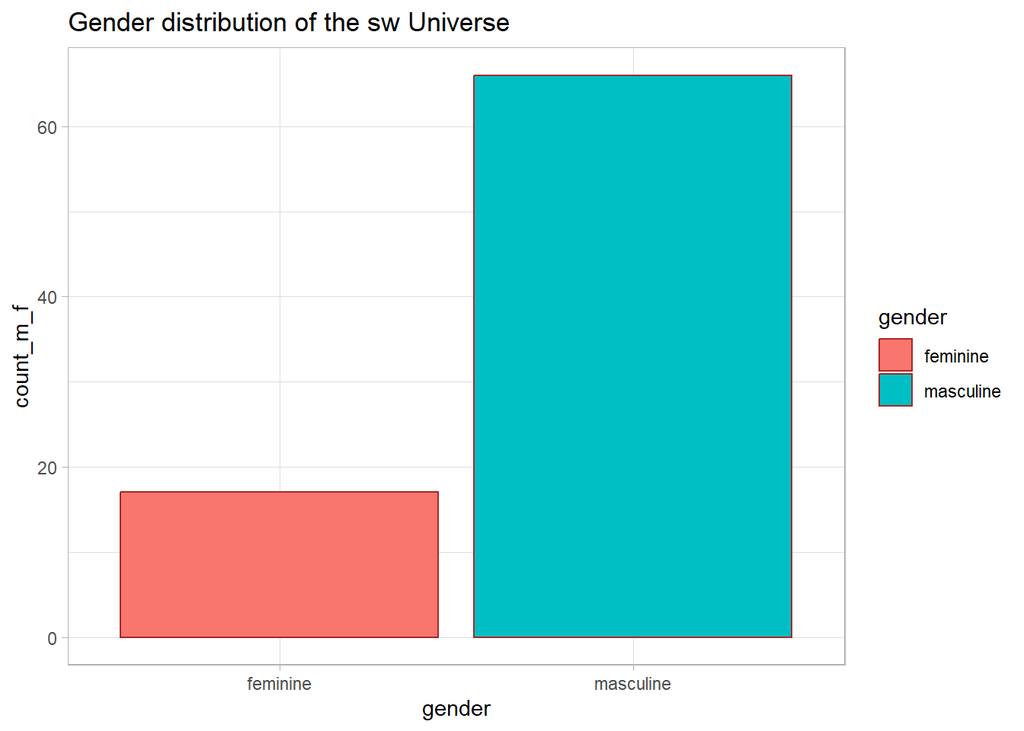

```r
starwars %>% drop_na(gender) %>% group_by(gender) %>% summarise(count_m_f=(n=n()))%>%ggplot(aes(x=gender,y=count_m_f),)+
  geom_bar(aes(fill=gender),stat = "identity", color = "brown") +
  labs(
    title = "Gender distribution of the sw Universe",
    xlab = "Gender",
    ylab= "Count"
  )+theme_light()
```

5.Draw the densities for the height variable of feminines and masculines only.

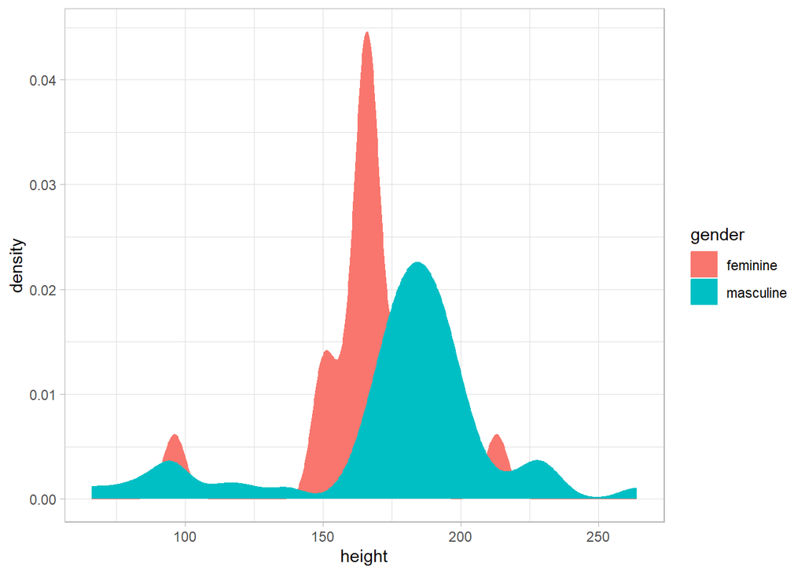

```r
starwars %>% drop_na(gender) %>% ggplot(aes(x=height,fill=gender))+geom_density(aes(col=gender))+theme_light()
```

6.Draw a segmented barplot for the variable ‘sex’. The colors depend on the hair colours. Show the proportions [0,1] on the y-axis.

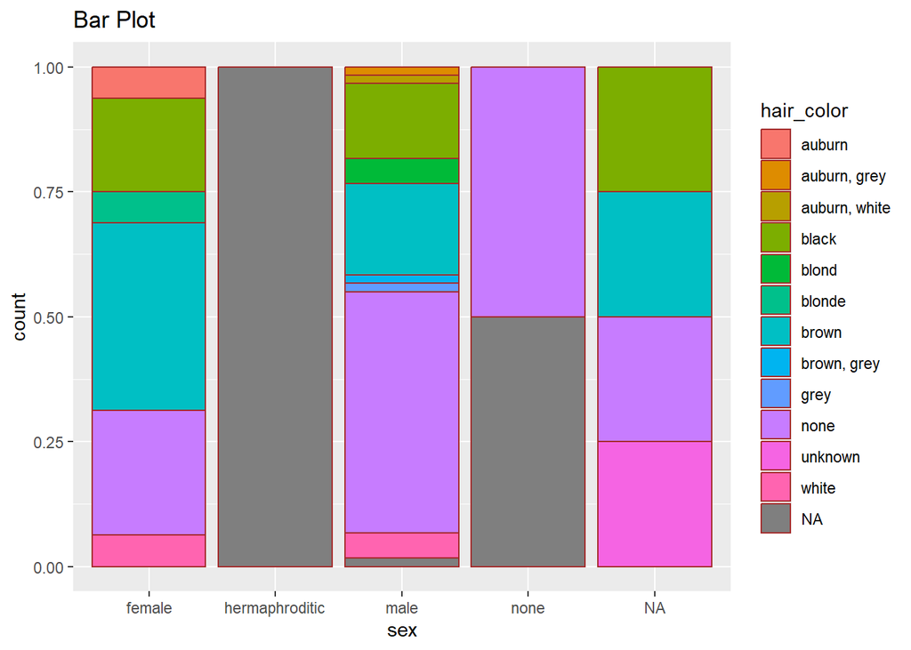

```r
# starwars

starwars %>% ggplot(aes(x=sex))+
  geom_bar(aes(fill=hair_color),position  = "fill", stat="count",col="Brown") +
  labs(
    title = "Bar Plot",
  )
```

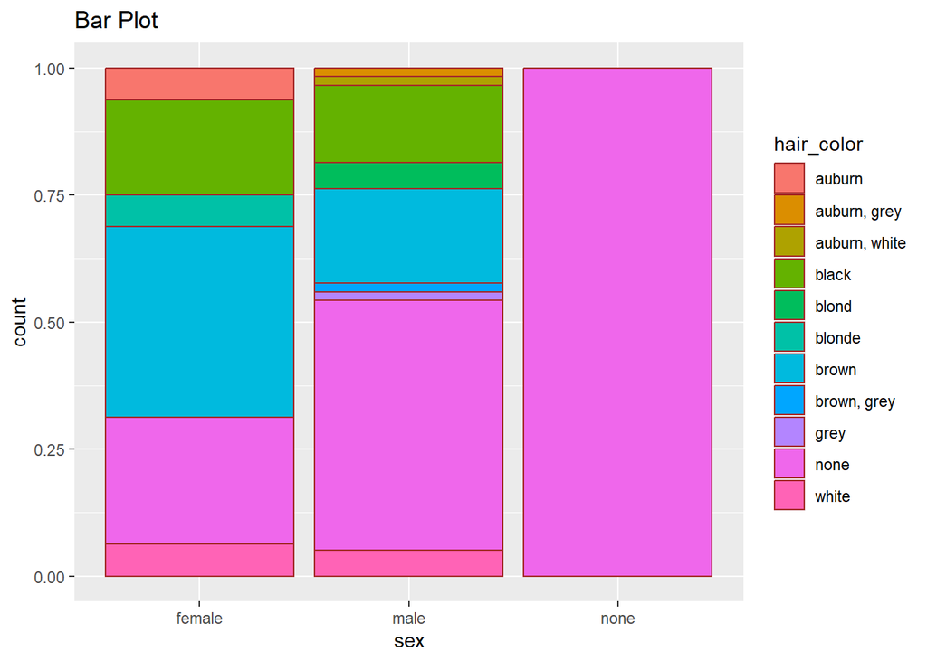

```r
# starwars

starwars %>% drop_na(hair_color,sex) %>% ggplot(aes(x=sex))+
  geom_bar(aes(fill=hair_color),position  = "fill", stat="count",col="Brown") +
  labs(
    title = "Bar Plot",
  )
```

#Exercise 4: festival

Read in the festival.csv file into a variable called festival.

1.Restructure and clean up the data a- In which tidy format, the data are ? b- Change this format in order to have observation per row and remove NA values (The 2 new columns must be day and cleanliness)

2. Draw a stripchart (geom_jitter) of the cleanliness values for males and females separately. a- Split the plot based on the day of the festival to see the effect this had on the data b- Personalize the point colors for males and females c- Add a line to show the mean
3. Add a new column called attendance to the data to say how many days people attended the festival.
4. Now redraw the plot but faceting by both attendance and day

```r
festival_data<- read.csv("C:\\Users\\praba\\Desktop\\uca1\\M1\\R programming\\class-6 workshop-3\\festival.csv")
festival_data
```

| person | gender | day1 | day2 | day3 |
| --- | --- | --- | --- | --- |
| 2111 | Male | 2.64 | 1.35 | 1.61 |
| 2229 | Female | 0.97 | 1.41 | 0.29 |
| 2338 | Male | 0.84 | NA | NA |
| 2384 | Female | 3.03 | NA | NA |
| 2401 | Female | 0.88 | 0.08 | NA |
| 2405 | Male | 0.85 | NA | NA |
| 2467 | Female | 1.56 | NA | NA |
| 2478 | Female | 3.02 | NA | NA |
| 2490 | Male | 2.29 | NA | NA |
| 2504 | Female | 1.11 | 0.44 | 0.55 |

[output cut: 800 more lines]

##1.Restructure and clean up the data a- In which tidy format, the data are ? b- Change this format in order to have observation per row and remove NA values (The 2 new columns must be day and cleanliness)

```r
library(tidyr)
```

```r
festival_data_tidy <- festival_data %>% pivot_longer(cols=day1:day3, names_to="day", values_to="cleanliness") %>% drop_na(cleanliness)
# dim(festival_data_tidy)
festival_data_tidy
```

| person | gender | day | cleanliness |
| --- | --- | --- | --- |
| 2111 | Male | day1 | 2.64 |
| 2111 | Male | day2 | 1.35 |
| 2111 | Male | day3 | 1.61 |
| 2229 | Female | day1 | 0.97 |
| 2229 | Female | day2 | 1.41 |
| 2229 | Female | day3 | 0.29 |
| 2338 | Male | day1 | 0.84 |
| 2384 | Female | day1 | 3.03 |
| 2401 | Female | day1 | 0.88 |
| 2401 | Female | day2 | 0.08 |

[output cut: 1187 more lines]

```r
# dim(df_titanic_drop)
festival_data_drop <- festival_data %>% pivot_longer(cols=day1:day3, names_to="day", values_to="cleanliness") %>% na.omit()
# dim(festival_data_drop)
festival_data_drop
```

| person | gender | day | cleanliness |
| --- | --- | --- | --- |
| 2111 | Male | day1 | 2.64 |
| 2111 | Male | day2 | 1.35 |
| 2111 | Male | day3 | 1.61 |
| 2229 | Female | day1 | 0.97 |
| 2229 | Female | day2 | 1.41 |
| 2229 | Female | day3 | 0.29 |
| 2338 | Male | day1 | 0.84 |
| 2384 | Female | day1 | 3.03 |
| 2401 | Female | day1 | 0.88 |
| 2401 | Female | day2 | 0.08 |

[output cut: 1187 more lines]

2. Draw a stripchart (geom_jitter) of the cleanliness values for males and females separately. a- Split the plot based on the day of the festival to see the effect this had on the data b- Personalize the point colors for males and females c- Add a line to show the mean

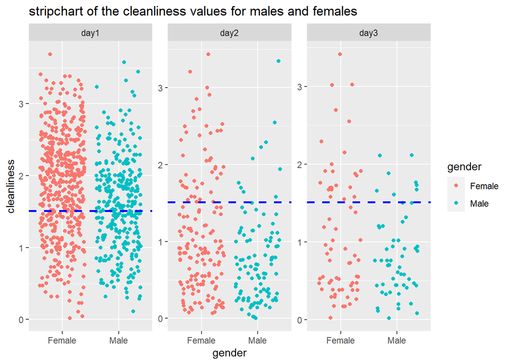

```r
festival_data_tidy<-festival_data %>% pivot_longer(cols=day1:day3, names_to="day", values_to="cleanliness") %>% drop_na(cleanliness)

festival_data_tidy %>%ggplot()+geom_jitter(aes(x=gender, y= cleanliness,col=gender))+
  geom_hline(yintercept = mean(festival_data_tidy$cleanliness, na.rm=TRUE), color='blue', lty='dashed', lwd=1)+
  facet_wrap(~ day, scales = "free")+
  labs(
    title= "stripchart of the cleanliness values for males and females",

  )+
  theme(legend.position="right")
```

###3. Add a new column called attendance to the data to say how many days people attended the festival.

```r
festival_data_clean<- festival_data %>% pivot_longer(cols=day1:day3, names_to="day", values_to="cleanliness") %>% drop_na(cleanliness)
festival_data_clean_data<-festival_data_clean %>% group_by(person) %>% summarise(attendance=(n=n()))
festival_data_clean_data
```

| person | attendance |
| --- | --- |
| 2111 | 3 |
| 2229 | 3 |
| 2338 | 1 |
| 2384 | 1 |
| 2401 | 2 |
| 2405 | 1 |
| 2467 | 1 |
| 2478 | 1 |
| 2490 | 1 |
| 2504 | 3 |

[output cut: 800 more lines]

```r
festival_data_clean_data_join <- left_join(festival_data, festival_data_clean_data, by ='person')
festival_data_clean_data_join
```

| person | gender | day1 | day2 | day3 | attendance |
| --- | --- | --- | --- | --- | --- |
| 2111 | Male | 2.64 | 1.35 | 1.61 | 3 |
| 2229 | Female | 0.97 | 1.41 | 0.29 | 3 |
| 2338 | Male | 0.84 | NA | NA | 1 |
| 2384 | Female | 3.03 | NA | NA | 1 |
| 2401 | Female | 0.88 | 0.08 | NA | 2 |
| 2405 | Male | 0.85 | NA | NA | 1 |
| 2467 | Female | 1.56 | NA | NA | 1 |
| 2478 | Female | 3.02 | NA | NA | 1 |
| 2490 | Male | 2.29 | NA | NA | 1 |
| 2504 | Female | 1.11 | 0.44 | 0.55 | 3 |

[output cut: 800 more lines]

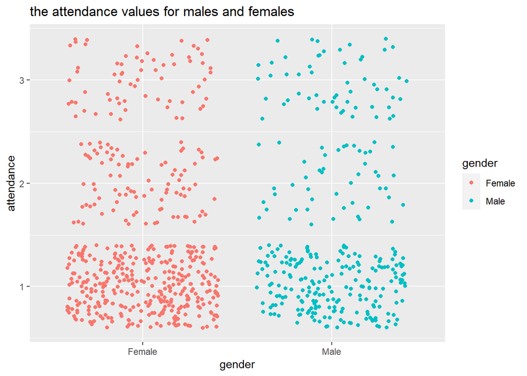

```r
festival_data_clean_data_join <- left_join(festival_data, festival_data_clean_data, by ='person')

festival_data_clean_data_join %>%ggplot()+geom_jitter(aes(x=gender, y= attendance,col=gender))+
  labs(
    title= "the attendance values for males and females",

  )+
  theme(legend.position="right")
```

```r
festival_data_clean<- festival_data %>% pivot_longer(cols=day1:day3, names_to="day", values_to="cleanliness") %>% drop_na(cleanliness)
festival_data_clean_data_day<-festival_data_clean %>% group_by(day) %>% summarise(attendance=(n=n()))
festival_data_clean_data_day
```

| day | attendance |
| --- | --- |
| day1 | 810 |
| day2 | 264 |
| day3 | 123 |

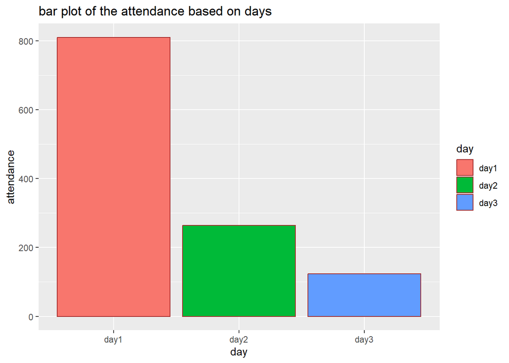

```r
festival_data_clean_data_day %>%ggplot()+geom_bar(aes(x=day, y= attendance,fill=day),col='Brown',stat='identity')+
  labs(
    title= "bar plot of the attendance based on days",

  )+
  theme(legend.position="right")
```